# Topic 8: Classification

Steven Cognac

2022-05-18

This week’s Rmd file here: https://github.com/MaRo406/EDS_231-text-sentiment/blob/main/topic_8.Rmd

This data set includes more *possible* predictors than the text alone, but for this model we will only use the text variable

```r
#download data spreadsheet here: #https://drive.google.com/file/d/1936GbWMjswqrOJuKfwik5vNmd0N4hPGF/view?usp=sharing
incidents_df <- read.csv(here("08_classification/climbing_reports_model_dat.csv"))
glimpse(incidents_df)
```

```
## Rows: 2,770
## Columns: 5
## $ ID               <chr> "1", "2", "3", "4", "5", "6", "7", "8", "9", "10", "1…
## $ Accident.Title   <chr> "Failure of Rappel Setup (Protection Pulled Out), Ina…
## $ Publication.Year <int> 1990, 1990, 1990, 1990, 1990, 1990, 1990, 1990, 1990,…
## $ Text             <chr> "Colorado, Rocky Mountain National Park\nOn May 7, 19…
## $ Deadly           <int> NA, NA, NA, NA, 1, 1, NA, NA, NA, NA, NA, 1, 1, NA, N…
```

Now we’ll split our data into training and test portions

```r
set.seed(1234)
incidents2class <- incidents_df %>%
  mutate(fatal = factor(if_else(
    is.na(Deadly) ,
    "non-fatal", "fatal")))


incidents_split <- initial_split(incidents2class, strata = fatal)

incidents_train <- training(incidents_split)
incidents_test <- testing(incidents_split)
```

We use recipe() to initialize our preprocessing transformations,specifying the predictor and outcome variables and the data.

```r
incidents_rec <- recipe(fatal ~ Text, data = incidents_train)
```

Next we add some familiar pre-processing steps on our Text variable: tokenize to word level, filter to the most common words, and calculate tf-idf.

```r
recipe <- incidents_rec %>%
  step_tokenize(Text) %>%
  step_tokenfilter(Text, max_tokens = 1000) %>%
  step_tfidf(Text)
```

Create tidymodels workflow to combine the modeling components

```r
incidents_wf <- workflow() %>%
  add_recipe(recipe)
```

```r
nb_spec <- naive_Bayes() %>%
  set_mode("classification") %>% #set modeling context
  set_engine("naivebayes") #method for fitting model

nb_spec
```

```
## Naive Bayes Model Specification (classification)
##
## Computational engine: naivebayes
```

Now we are ready to add our model to the workflow and fit it to the training data

```r
nb_fit <- incidents_wf %>%
  add_model(nb_spec) %>%
  fit(data = incidents_train)
```

Next up is model evaluation. We can stretch our training data a little further and use resampled data sets built from the training set to evaluate our naive Bayes model. Here we create 10-fold cross-validation sets, and use them performance estimates.

```r
set.seed(234)
incidents_folds <- vfold_cv(incidents_train) #default is v = 10

incidents_folds
```

```
## #  10-fold cross-validation
## # A tibble: 10 × 2
##    splits             id
##    <list>             <chr>
##  1 <split [1869/208]> Fold01
##  2 <split [1869/208]> Fold02
##  3 <split [1869/208]> Fold03
##  4 <split [1869/208]> Fold04
##  5 <split [1869/208]> Fold05
##  6 <split [1869/208]> Fold06
##  7 <split [1869/208]> Fold07
##  8 <split [1870/207]> Fold08
##  9 <split [1870/207]> Fold09
## 10 <split [1870/207]> Fold10
```

```r
nb_wf <- workflow() %>%
  add_recipe(recipe) %>%
  add_model(nb_spec)

nb_wf
```

```
## ══ Workflow ════════════════════════════════════════════════════════════════════
## Preprocessor: Recipe
## Model: naive_Bayes()
##
## ── Preprocessor ────────────────────────────────────────────────────────────────
## 3 Recipe Steps
##
## • step_tokenize()
## • step_tokenfilter()
## • step_tfidf()
##
## ── Model ───────────────────────────────────────────────────────────────────────
## Naive Bayes Model Specification (classification)
##
## Computational engine: naivebayes
```

To estimate its performance, we fit the model many times, once to each of these resampled folds, and then evaluate on the heldout part of each resampled fold.

```r
nb_rs <- fit_resamples(
  nb_wf,
  incidents_folds,
  control = control_resamples(save_pred = TRUE)
)
```

Extract the relevant information using collect_metrics() and collect_predictions() and examine the performance metrics.

```r
nb_rs_metrics <- collect_metrics(nb_rs)
nb_rs_predictions <- collect_predictions(nb_rs)
nb_rs_metrics
```

```
## # A tibble: 2 × 6
##   .metric  .estimator  mean     n std_err .config
##   <chr>    <chr>      <dbl> <int>   <dbl> <chr>
## 1 accuracy binary     0.800    10 0.00474 Preprocessor1_Model1
## 2 roc_auc  binary     0.735    10 0.0131  Preprocessor1_Model1
```

We’ll use two performance metrics: accuracy and ROC AUC. Accuracy is the proportion of the data that is predicted correctly. The ROC curve plots the true positive rate against the false positive rate; AUC closer to 1 indicates a better-performing model, while AUC closer to 0.5 indicates a model that does no better than random guessing.

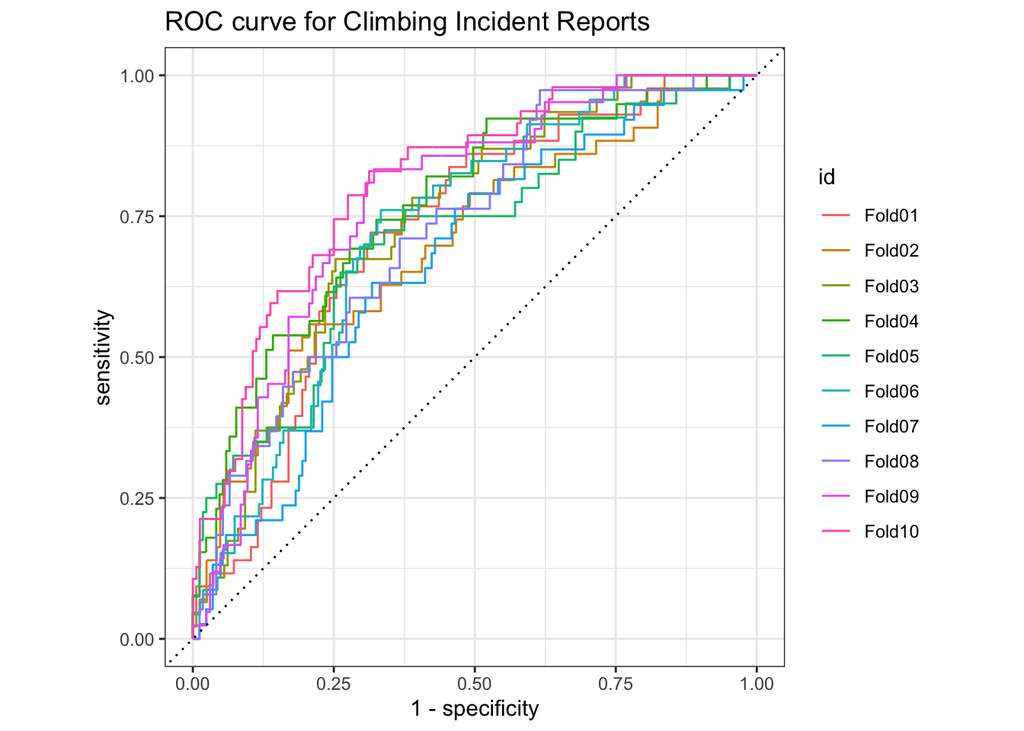

```r
nb_rs_predictions %>%
  group_by(id) %>%
  roc_curve(truth = fatal, .pred_fatal) %>%
  autoplot() +
  labs(
    "Resamples",
    title = "ROC curve for Climbing Incident Reports"
  )
```

Another model method involves the confusion matrix. A confusion matrix tabulates a model’s false positives and false negatives for each class.

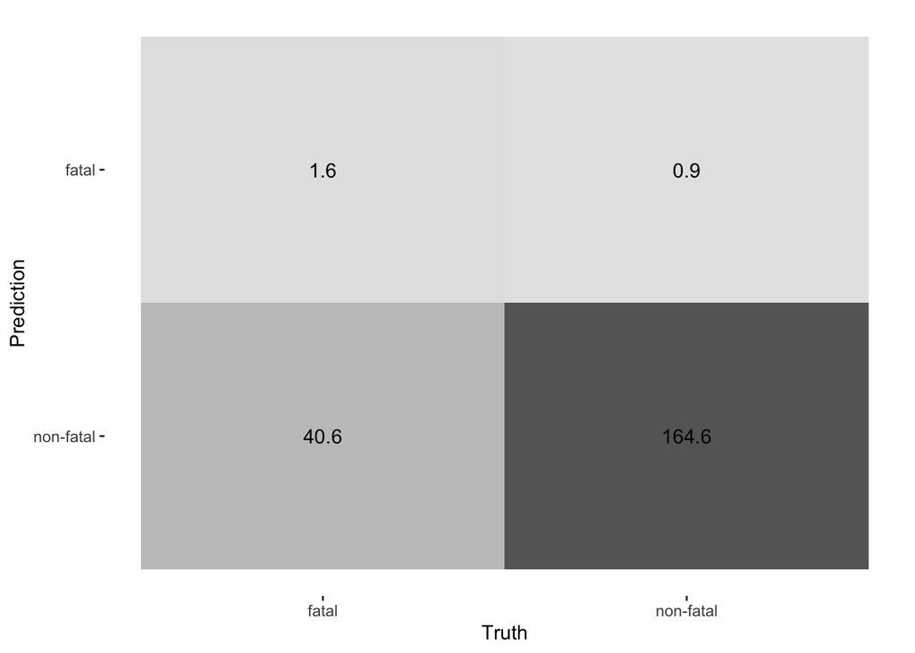

```r
conf_mat_resampled(nb_rs, tidy = FALSE) %>% #compute matrix for each fold then average
  autoplot(type = "heatmap")
```

```r
null_classification <- null_model() %>%
  set_engine("parsnip") %>% #parsnip package
  set_mode("classification")

null_rs <- workflow() %>%
  add_recipe(recipe) %>%
  add_model(null_classification) %>%
  fit_resamples(
    incidents_folds
  )
```

Let’s move up to a more sophisticated model. A lasso classification model uses regularization to help us choose a simpler, more generalizable model. Variable selection helps us identify which features to include in our model.

Lasso classification learns how much of a penalty to put on features to reduce the high-dimensional space of original possible variables (tokens) for the final model.

```r
lasso_spec <- logistic_reg(penalty = 0.01, mixture = 1) %>% #glm for binary outcomes
  set_mode("classification") %>%
  set_engine("glmnet") #estimation method for classification

lasso_spec
```

```
## Logistic Regression Model Specification (classification)
##
## Main Arguments:
##   penalty = 0.01
##   mixture = 1
##
## Computational engine: glmnet
```

```r
lasso_wf <- workflow() %>%
  add_recipe(recipe) %>%
  add_model(lasso_spec)

lasso_wf
```

```
## ══ Workflow ════════════════════════════════════════════════════════════════════
## Preprocessor: Recipe
## Model: logistic_reg()
##
## ── Preprocessor ────────────────────────────────────────────────────────────────
## 3 Recipe Steps
##
## • step_tokenize()
## • step_tokenfilter()
## • step_tfidf()
##
## ── Model ───────────────────────────────────────────────────────────────────────
## Logistic Regression Model Specification (classification)
##
## Main Arguments:
##   penalty = 0.01
##   mixture = 1
##
## Computational engine: glmnet
```

```r
set.seed(2020)
lasso_rs <- fit_resamples(
  lasso_wf,
  incidents_folds,
  control = control_resamples(save_pred = TRUE)
)

#pull out metric and predictino
lasso_rs_metrics <- collect_metrics(lasso_rs)
lasso_rs_predictions <- collect_predictions(lasso_rs)

lasso_rs_metrics
```

```
## # A tibble: 2 × 6
##   .metric  .estimator  mean     n std_err .config
##   <chr>    <chr>      <dbl> <int>   <dbl> <chr>
## 1 accuracy binary     0.895    10 0.00538 Preprocessor1_Model1
## 2 roc_auc  binary     0.947    10 0.00593 Preprocessor1_Model1
```

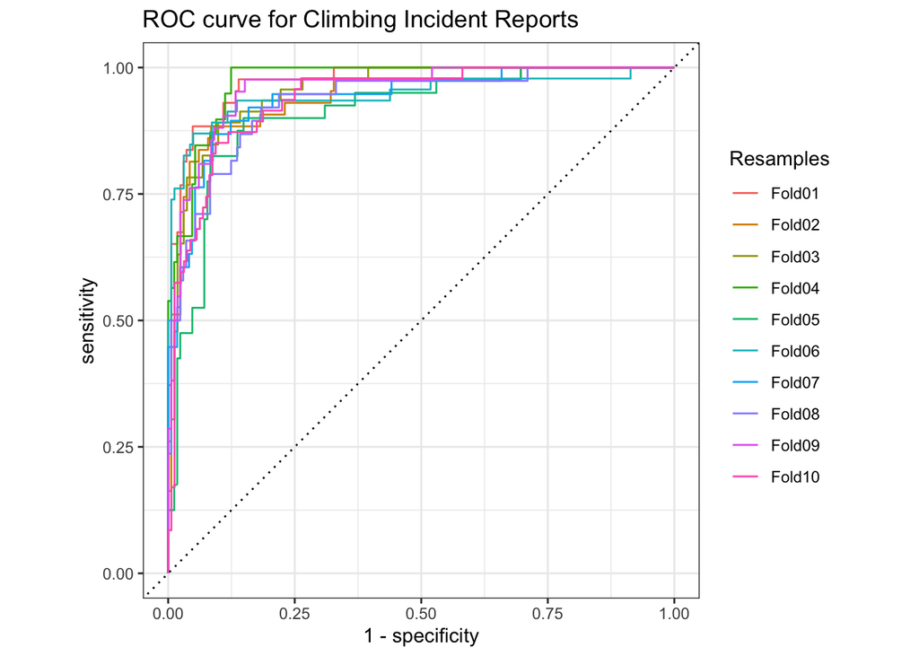

```r
lasso_rs_predictions %>%
  group_by(id) %>%
  roc_curve(truth = fatal, .pred_fatal) %>%
  autoplot() +
  labs(
    color = "Resamples",
    title = "ROC curve for Climbing Incident Reports",
  )
```

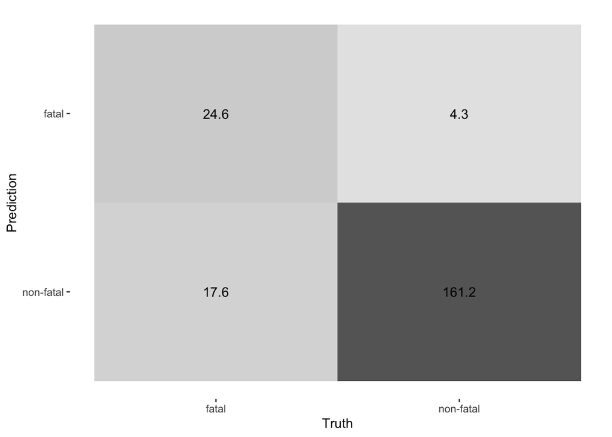

```r
conf_mat_resampled(lasso_rs, tidy = FALSE) %>%
  autoplot(type = "heatmap")
```

The value penalty = 0.01 is a model hyperparameter. The higher it is, the more model coefficients are reduced (sometimes to 0, removing them – feature selection) We set it manually before, but we can also estimate its best value, again by training many models on resampled data sets and examining their performance.

```r
tune_spec <- logistic_reg(penalty = tune(), mixture = 1) %>%
  set_mode("classification") %>%
  set_engine("glmnet")

tune_spec
```

```
## Logistic Regression Model Specification (classification)
##
## Main Arguments:
##   penalty = tune()
##   mixture = 1
##
## Computational engine: glmnet
```

```r
lambda_grid <- grid_regular(penalty(), levels = 30)
lambda_grid
```

```
## # A tibble: 30 × 1
##     penalty
##       <dbl>
##  1 1   e-10
##  2 2.21e-10
##  3 4.89e-10
##  4 1.08e- 9
##  5 2.40e- 9
##  6 5.30e- 9
##  7 1.17e- 8
##  8 2.59e- 8
##  9 5.74e- 8
## 10 1.27e- 7
## # … with 20 more rows
```

Here we use grid_regular() to create 30 possible values for the regularization penalty. Then tune_grid() fits a model at each of those values.

```r
tune_wf <- workflow() %>%
  add_recipe(recipe) %>%
  add_model(tune_spec)

set.seed(2020)
tune_rs <- tune_grid(
  tune_wf,
  incidents_folds,
  grid = lambda_grid,
  control = control_resamples(save_pred = TRUE)
)

tune_rs
```

```
## # Tuning results
## # 10-fold cross-validation
## # A tibble: 10 × 5
##    splits             id     .metrics          .notes           .predictions
##    <list>             <chr>  <list>            <list>           <list>
##  1 <split [1869/208]> Fold01 <tibble [60 × 5]> <tibble [0 × 1]> <tibble>
##  2 <split [1869/208]> Fold02 <tibble [60 × 5]> <tibble [0 × 1]> <tibble>
##  3 <split [1869/208]> Fold03 <tibble [60 × 5]> <tibble [0 × 1]> <tibble>
##  4 <split [1869/208]> Fold04 <tibble [60 × 5]> <tibble [0 × 1]> <tibble>
##  5 <split [1869/208]> Fold05 <tibble [60 × 5]> <tibble [0 × 1]> <tibble>
##  6 <split [1869/208]> Fold06 <tibble [60 × 5]> <tibble [0 × 1]> <tibble>
##  7 <split [1869/208]> Fold07 <tibble [60 × 5]> <tibble [0 × 1]> <tibble>
##  8 <split [1870/207]> Fold08 <tibble [60 × 5]> <tibble [0 × 1]> <tibble>
##  9 <split [1870/207]> Fold09 <tibble [60 × 5]> <tibble [0 × 1]> <tibble>
## 10 <split [1870/207]> Fold10 <tibble [60 × 5]> <tibble [0 × 1]> <tibble>
```

collect_metrics(tune_rs)

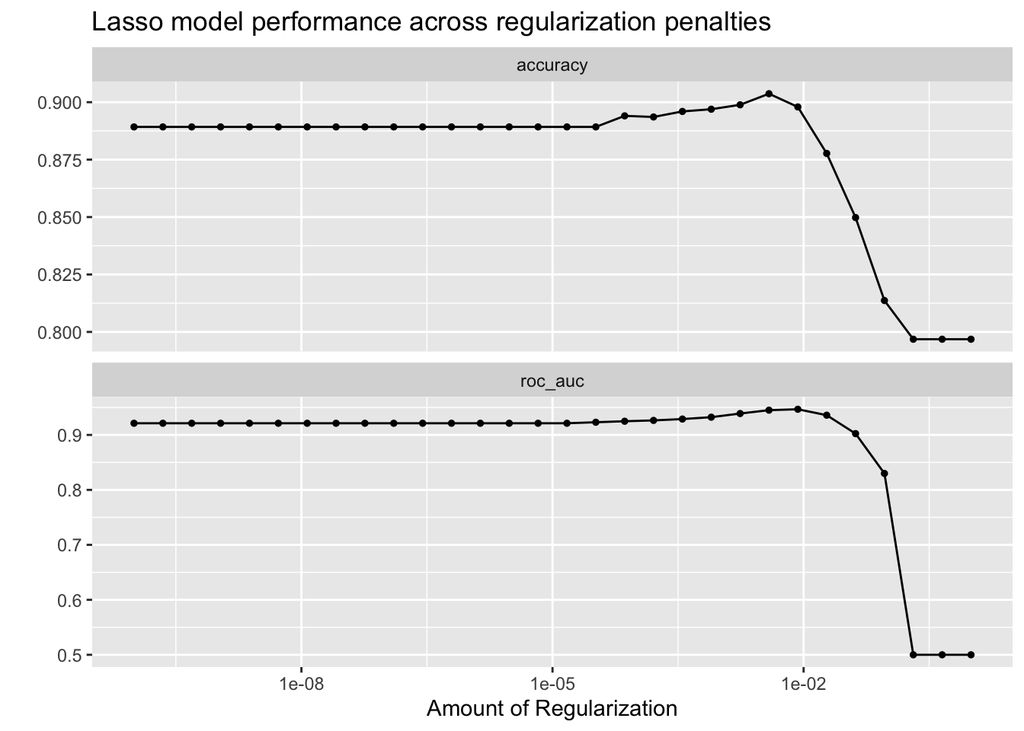

```r
autoplot(tune_rs) +
  labs(
    title = "Lasso model performance across regularization penalties"
  )
```

```r
 tune_rs %>%
  show_best("roc_auc")
```

```
## # A tibble: 5 × 7
##    penalty .metric .estimator  mean     n std_err .config
##      <dbl> <chr>   <chr>      <dbl> <int>   <dbl> <chr>
## 1 0.00853  roc_auc binary     0.947    10 0.00586 Preprocessor1_Model24
## 2 0.00386  roc_auc binary     0.945    10 0.00532 Preprocessor1_Model23
## 3 0.00174  roc_auc binary     0.939    10 0.00500 Preprocessor1_Model22
## 4 0.0189   roc_auc binary     0.936    10 0.00596 Preprocessor1_Model25
## 5 0.000788 roc_auc binary     0.932    10 0.00527 Preprocessor1_Model21
```

```r
tune_rs %>%
  show_best("accuracy")
```

```
## # A tibble: 5 × 7
##    penalty .metric  .estimator  mean     n std_err .config
##      <dbl> <chr>    <chr>      <dbl> <int>   <dbl> <chr>
## 1 0.00386  accuracy binary     0.904    10 0.00581 Preprocessor1_Model23
## 2 0.00174  accuracy binary     0.899    10 0.00672 Preprocessor1_Model22
## 3 0.00853  accuracy binary     0.898    10 0.00516 Preprocessor1_Model24
## 4 0.000788 accuracy binary     0.897    10 0.00624 Preprocessor1_Model21
## 5 0.000356 accuracy binary     0.896    10 0.00648 Preprocessor1_Model20
```

```r
chosen_acc <- tune_rs %>%
  select_by_one_std_err(metric = "accuracy", -penalty)

chosen_acc
```

```
## # A tibble: 1 × 9
##   penalty .metric  .estimator  mean     n std_err .config           .best .bound
##     <dbl> <chr>    <chr>      <dbl> <int>   <dbl> <chr>             <dbl>  <dbl>
## 1 0.00853 accuracy binary     0.898    10 0.00516 Preprocessor1_Mo… 0.904  0.898
```

Next, let’s finalize our tunable workflow with this particular regularization penalty. This is the regularization penalty that our tuning results indicate give us the best model.

```r
final_lasso <- finalize_workflow(tune_wf, chosen_acc)

final_lasso
```

```
## ══ Workflow ════════════════════════════════════════════════════════════════════
## Preprocessor: Recipe
## Model: logistic_reg()
##
## ── Preprocessor ────────────────────────────────────────────────────────────────
## 3 Recipe Steps
##
## • step_tokenize()
## • step_tokenfilter()
## • step_tfidf()
##
## ── Model ───────────────────────────────────────────────────────────────────────
## Logistic Regression Model Specification (classification)
##
## Main Arguments:
##   penalty = 0.00853167852417281
##   mixture = 1
##
## Computational engine: glmnet
```

The penalty argument value now reflects our tuning result. Now we fit to our training data.

```r
fitted_lasso <- fit(final_lasso, incidents_train)
```

First let’s look at the words associated with an accident being non-fatal.

```r
fitted_lasso %>%
  extract_fit_parsnip() %>%
  tidy() %>%
  arrange(-estimate)
```

```
## # A tibble: 1,001 × 3
##    term                 estimate penalty
##    <chr>                   <dbl>   <dbl>
##  1 tfidf_Text_analysis      90.9 0.00853
##  2 tfidf_Text_hospital      78.6 0.00853
##  3 tfidf_Text_treatment     55.9 0.00853
##  4 tfidf_Text_fractures     47.5 0.00853
##  5 tfidf_Text_injury        47.5 0.00853
##  6 tfidf_Text_pain          44.1 0.00853
##  7 tfidf_Text_helped        43.6 0.00853
##  8 tfidf_Text_able          41.7 0.00853
##  9 tfidf_Text_broken        36.9 0.00853
## 10 tfidf_Text_condition     35.3 0.00853
## # … with 991 more rows
```

And now the words that are most associated with a fatal incident.

```r
fitted_lasso %>%
  extract_fit_parsnip() %>%
  tidy() %>%
  arrange(estimate)
```

```
## # A tibble: 1,001 × 3
##    term                 estimate penalty
##    <chr>                   <dbl>   <dbl>
##  1 tfidf_Text_died        -277.  0.00853
##  2 tfidf_Text_body        -158.  0.00853
##  3 tfidf_Text_death       -132.  0.00853
##  4 tfidf_Text_fatal        -76.8 0.00853
##  5 tfidf_Text_breathing    -47.7 0.00853
##  6 tfidf_Text_past         -32.5 0.00853
##  7 tfidf_Text_observed     -32.5 0.00853
##  8 tfidf_Text_occurred     -31.7 0.00853
##  9 tfidf_Text_noticed      -31.1 0.00853
## 10 tfidf_Text_either       -31.0 0.00853
## # … with 991 more rows
```